# Explainable AI

Erklärbarkeit maschineller Lernverfahren

## Inhalte

- **Überblick**
- **Anwendungsbeispiele**
- **Strategien**
- **Beispiel**
- **Demo (LIME)**
- **Stand der Forschung/Fazit**

[figure not shown]

https://cdn-images-1.medium.com/max/1600/1*szl70qMtCfOrY36q3W5pqQ.png

### Black-Box-Modelle im Alltag

[figure not shown]

https://mk0analyticsindf35n9.kinstacdn.com/wp-content/uploads/2020/04/Learn-Facial-Recognition-scaled.jpg

[figure not shown]

https://cdn.shortpixel.ai/client/to_webp,q_lossless,ret_img,w_540,h_280/https://ebusinessinstitute.com/wp-content/uploads/2018/06/voice-technology-assistants.jpg

[figure not shown]

https://www.scinexx.de/wp-content/uploads/s/t/studie_autonomes_fahren-1.jpeg

[figure not shown]

https://i.imgur.com/1FfL1M1.jpg

### Einordnung

- Koexistenz zu Künstlicher Intelligenz

### Nomenklatur

- Explainable Expert Systems
- Explanations in Knowledge Systems
- Explainable Decision Support Systems
- Explainable Artificial Intelligence

### Strategien

[figure not shown]

https://labs.sogeti.com/wp-content/uploads/2019/05/1.jpg

Ribeiro MT, Singh S, Guestrin C. **’Why should I trust you?’** Explaining the predictions of any classifier. In: Proceedings of the 22nd ACM SIGKDD international conference on knowledge discovery and data mining; 2016. S. 1135–1144.

## Local Interpretable Model-Agnostic Explanations (LIME)

- Erklärung konkreter Entscheidungen $\neq$ gesamtes System verstehen
- Reduktion des Modells auf einen konkreten Ein-/Ausgabebereich

**Agnostischer Ansatz:** LIME ist modellunabhängig

**Modellspezifischer Ansatz:** Interne Komponenten und ihre Interaktionen analysieren

LIME hilft bei der Beantwortung der Frage, warum wurde diese Vorhersage gemacht oder welche Variablen haben diese Vorhersage verursacht?

[figure not shown]

https://miro.medium.com/max/1400/1*k-rxjnvUDTwk8Jfg6IYBkQ.png

[figure not shown]

https://theblue.ai/blog/lime-models-explanation/

## 'Why should I trust you?'

[figure not shown]

https://theblue.ai/blog/lime-models-explanation/

[figure not shown]

https://theblue.ai/wp-content/uploads/2019/04/figure3.jpg

[figure not shown]

https://theblue.ai/wp-content/uploads/2019/04/figure4.jpg

## Demo Bilder

```python
model = models.inception_v3(pretrained=True)
```

```python
idx2label, cls2label, cls2idx = [], {}, {}
with open(os.path.abspath('data/imagenet_class_index.json'), 'r') as read_file:
    class_idx = json.load(read_file)
    idx2label = [class_idx[str(k)][1] for k in range(len(class_idx))]
    cls2label = {class_idx[str(k)][0]: class_idx[str(k)][1] for k in range(len(class_idx))}
    cls2idx = {class_idx[str(k)][0]: k for k in range(len(class_idx))}
```

```python
print(cls2label)
```

[output not shown]

```python
print(len(cls2label))
```

```
1000
```

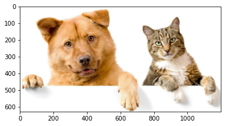

```python
img = get_image('dog-and-cat-cover.jpg')
plt.imshow(img)
```

```python
probs = F.softmax(logits, dim=1)
probs5 = probs.topk(5)
tuple((p,c, idx2label[c]) for p, c in zip(probs5[0][0].detach().numpy(), probs5[1][0].detach().numpy()))
```

```
((0.999841, 260, 'chow'),
 (2.8184546e-05, 207, 'golden_retriever'),
 (1.9220884e-05, 235, 'German_shepherd'),
 (1.5166565e-05, 193, 'Australian_terrier'),
 (1.1747476e-05, 282, 'tiger_cat'))
```

```python
explainer = lime_image.LimeImageExplainer()
explanation = explainer.explain_instance(np.array(pill_transf(img)),
                                         batch_predict, # classification function
                                         top_labels=5,
                                         hide_color=0,
                                         num_samples=1000) # number of images that will be sent to classification function
```

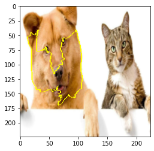

```python
temp, mask = explanation.get_image_and_mask(explanation.top_labels[0], positive_only=True, num_features=5, hide_rest=False)
img_boundry1 = mark_boundaries(temp/255.0, mask)
plt.imshow(img_boundry1)
```

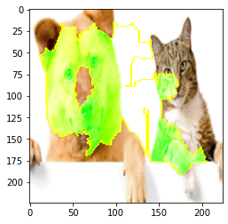

```python
temp, mask = explanation.get_image_and_mask(explanation.top_labels[0], positive_only=False, num_features=10, hide_rest=False)
img_boundry2 = mark_boundaries(temp/255.0, mask)
plt.imshow(img_boundry2)
```

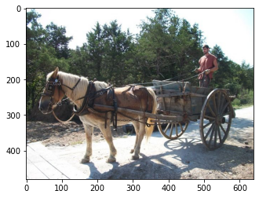

```python
img = get_image('horse_cart.jpg')
plt.imshow(img)
```

```python
probs = F.softmax(logits, dim=1)
probs5 = probs.topk(5)
tuple((p,c, idx2label[c]) for p, c in zip(probs5[0][0].detach().numpy(), probs5[1][0].detach().numpy()))
```

```
((0.9999976, 603, 'horse_cart'),
 (6.566204e-07, 690, 'oxcart'),
 (3.7934126e-07, 730, 'plow'),
 (2.0215273e-07, 537, 'dogsled'),
 (1.5093039e-07, 676, 'muzzle'))
```

```python
explainer = lime_image.LimeImageExplainer()
explanation = explainer.explain_instance(np.array(pill_transf(img)),
                                         batch_predict, # classification function
                                         top_labels=5,
                                         hide_color=0,
                                         num_samples=1000) # number of images that will be sent to classification function
```

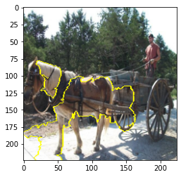

```python
temp, mask = explanation.get_image_and_mask(explanation.top_labels[0], positive_only=True, num_features=5, hide_rest=False)
img_boundry1 = mark_boundaries(temp/255.0, mask)
plt.imshow(img_boundry1)
```

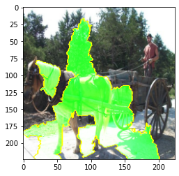

```python
temp, mask = explanation.get_image_and_mask(explanation.top_labels[0], positive_only=False, num_features=10, hide_rest=False)
img_boundry2 = mark_boundaries(temp/255.0, mask)
plt.imshow(img_boundry2)
```

[figure not shown]

```python
img = get_image('cat_cart.jpg')
plt.imshow(img)
```

```python
probs = F.softmax(logits, dim=1)
probs5 = probs.topk(5)
tuple((p,c, idx2label[c]) for p, c in zip(probs5[0][0].detach().numpy(), probs5[1][0].detach().numpy()))
```

```
((0.559592, 603, 'horse_cart'),
 (0.23449965, 612, 'jinrikisha'),
 (0.0399608, 870, 'tricycle'),
 (0.03494276, 537, 'dogsled'),
 (0.028129118, 456, 'bow'))
```

```python
explainer = lime_image.LimeImageExplainer()
explanation = explainer.explain_instance(np.array(pill_transf(img)),
                                         batch_predict, # classification function
                                         top_labels=5,
                                         hide_color=0,
                                         num_samples=1000) # number of images that will be sent to classification function
```

[figure not shown]

```python
temp, mask = explanation.get_image_and_mask(explanation.top_labels[0], positive_only=True, num_features=5, hide_rest=False)
img_boundry1 = mark_boundaries(temp/255.0, mask)
plt.imshow(img_boundry1)
```

[figure not shown]

```python
temp, mask = explanation.get_image_and_mask(explanation.top_labels[0], positive_only=False, num_features=10, hide_rest=False)
img_boundry2 = mark_boundaries(temp/255.0, mask)
plt.imshow(img_boundry2)
```

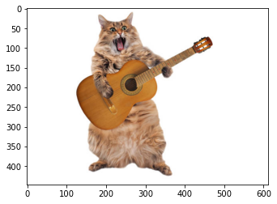

```python
img = get_image('cat_acoustic_guitar.jpg')
plt.imshow(img)
```

```python
probs = F.softmax(logits, dim=1)
probs5 = probs.topk(5)
tuple((p,c, idx2label[c]) for p, c in zip(probs5[0][0].detach().numpy(), probs5[1][0].detach().numpy()))
```

```
((0.986264, 402, 'acoustic_guitar'),
 (0.0052733794, 546, 'electric_guitar'),
 (0.004002535, 889, 'violin'),
 (0.0019818842, 420, 'banjo'),
 (0.00058239984, 486, 'cello'))
```

```python
explainer = lime_image.LimeImageExplainer()
explanation = explainer.explain_instance(np.array(pill_transf(img)),
                                         batch_predict, # classification function
                                         top_labels=5,
                                         hide_color=0,
                                         num_samples=1000) # number of images that will be sent to classification function
```

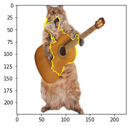

```python
temp, mask = explanation.get_image_and_mask(explanation.top_labels[0], positive_only=True, num_features=5, hide_rest=False)
img_boundry1 = mark_boundaries(temp/255.0, mask)
plt.imshow(img_boundry1)
```

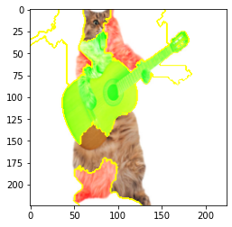

```python
temp, mask = explanation.get_image_and_mask(explanation.top_labels[0], positive_only=False, num_features=10, hide_rest=False)
img_boundry2 = mark_boundaries(temp/255.0, mask)
plt.imshow(img_boundry2)
```

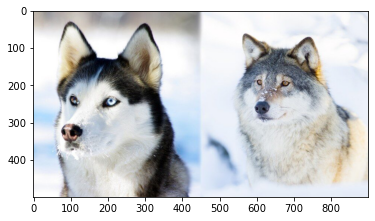

```python
img = get_image('husky_vs_wolf.jpg')
plt.imshow(img)
```

```python
probs = F.softmax(logits, dim=1)
probs5 = probs.topk(5)
tuple((p,c, idx2label[c]) for p, c in zip(probs5[0][0].detach().numpy(), probs5[1][0].detach().numpy()))
```

```
((0.836655, 248, 'Eskimo_dog'),
 (0.16187002, 250, 'Siberian_husky'),
 (0.00077935855, 249, 'malamute'),
 (0.00020769074, 537, 'dogsled'),
 (0.00016534832, 269, 'timber_wolf'))
```

```python
explainer = lime_image.LimeImageExplainer()
explanation = explainer.explain_instance(np.array(pill_transf(img)),
                                         batch_predict, # classification function
                                         top_labels=5,
                                         hide_color=0,
                                         num_samples=1000) # number of images that will be sent to classification function
```

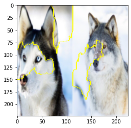

```python
temp, mask = explanation.get_image_and_mask(explanation.top_labels[0], positive_only=True, num_features=5, hide_rest=False)
img_boundry1 = mark_boundaries(temp/255.0, mask)
plt.imshow(img_boundry1)
```

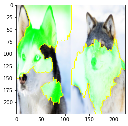

```python
temp, mask = explanation.get_image_and_mask(explanation.top_labels[0], positive_only=False, num_features=10, hide_rest=False)
img_boundry2 = mark_boundaries(temp/255.0, mask)
plt.imshow(img_boundry2)
```

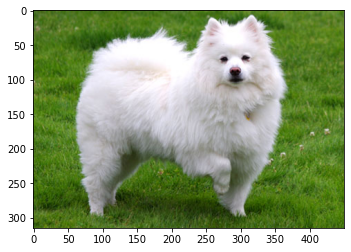

```python
img = get_image('eskimo_dog.jpg')
plt.imshow(img)
```

```python
img_t = get_input_tensors(img)
model.eval()
logits = model(img_t)
```

```python
probs = F.softmax(logits, dim=1)
probs5 = probs.topk(5)
tuple((p,c, idx2label[c]) for p, c in zip(probs5[0][0].detach().numpy(), probs5[1][0].detach().numpy()))
```

```
((0.99511445, 258, 'Samoyed'),
 (0.004814896, 260, 'chow'),
 (4.5010795e-05, 261, 'keeshond'),
 (1.2006684e-05, 257, 'Great_Pyrenees'),
 (4.0161012e-06, 259, 'Pomeranian'))
```

```python
explainer = lime_image.LimeImageExplainer()
explanation = explainer.explain_instance(np.array(pill_transf(img)),
                                         batch_predict, # classification function
                                         top_labels=5,
                                         hide_color=0,
                                         num_samples=1000) # number of images that will be sent to classification function
```

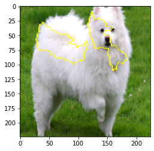

```python
temp, mask = explanation.get_image_and_mask(explanation.top_labels[0], positive_only=True, num_features=5, hide_rest=False)
img_boundry1 = mark_boundaries(temp/255.0, mask)
plt.imshow(img_boundry1)
```

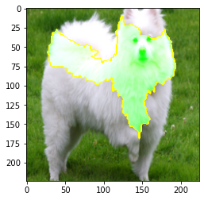

```python
temp, mask = explanation.get_image_and_mask(explanation.top_labels[0], positive_only=False, num_features=10, hide_rest=False)
img_boundry2 = mark_boundaries(temp/255.0, mask)
plt.imshow(img_boundry2)
```

### Eskimo Dog vs. Samojede

[figure not shown]

https://i.ytimg.com/vi/8jAkTfD86os/hqdefault.jpg

## Demo Texte (the 20 newsgroups text dataset)

- Der Datensatz umfasst rund 18.000 Forum-Beiträge zu 20 Themen
- Aufgeteilt in zwei Untergruppen: ein Datensatz für Training (oder Entwicklung) und der andere für Tests
- Die Aufteilung zwischen Trainings- und Testdatensatz basiert auf Nachrichten, die vor und nach einem bestimmten Datum veröffentlicht wurden

```python
from sklearn.datasets import fetch_20newsgroups
categories = ['alt.atheism', 'soc.religion.christian']
newsgroups_train = fetch_20newsgroups(subset='train', categories=categories)
newsgroups_test = fetch_20newsgroups(subset='test', categories=categories)
class_names = ['atheism', 'christian']
```

```python
from lime.lime_text import LimeTextExplainer
explainer = LimeTextExplainer(class_names=class_names)
```

```python
idx = 66
exp = explainer.explain_instance(newsgroups_test.data[idx], c.predict_proba)
print('Document id: %d' % idx)
print('Probability(christian) =', c.predict_proba([newsgroups_test.data[idx]])[0,1])
print('True class: %s' % class_names[newsgroups_test.target[idx]])
```

```
Document id: 66
Probability(christian) = 0.076
True class: atheism
```

```python
exp.as_list()
```

```
[('Posting', -0.051927772791213495),
 ('Host', -0.05074981231807156),
 ('NNTP', -0.049132013697342956),
 ('Re', -0.04572329555306849),
 ('writes', -0.04362622479277363),
 ('de', -0.04009244185206005),
 ('Benedikt', -0.03660272454376937),
 ('dbstu1', -0.036130584896408365),
 ('tu', -0.035166520372064795),
 ('bs', -0.034117865504404016)]
```

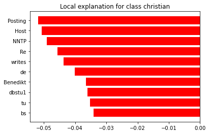

```python
%matplotlib inline
fig = exp.as_pyplot_figure()
```

[figure not shown]

```python
idx = 88
exp = explainer.explain_instance(newsgroups_test.data[idx], c.predict_proba)
print('Document id: %d' % idx)
print('Probability(christian) =', c.predict_proba([newsgroups_test.data[idx]])[0,1])
print('True class: %s' % class_names[newsgroups_test.target[idx]])
```

```
Document id: 88
Probability(christian) = 0.83
True class: christian
```

```python
exp.as_list()
```

```
[('rutgers', 0.06458767353897933),
 ('athos', 0.03275281175734924),
 ('1993', 0.030955033038031283),
 ('Re', -0.028132283922869074),
 ('writes', -0.025081109762373183),
 ('article', -0.018907205659329525),
 ('In', -0.014418263681473524),
 ('edu', -0.011639856443708236),
 ('world', -0.010095259016752274),
 ('Technical', -0.007489173120520363)]
```

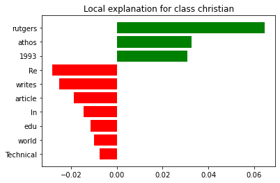

```python
%matplotlib inline
fig = exp.as_pyplot_figure()
```

[figure not shown]

```python
idx = 12
exp = explainer.explain_instance(newsgroups_test.data[idx], c.predict_proba)
print('Document id: %d' % idx)
print('Probability(christian) =', c.predict_proba([newsgroups_test.data[idx]])[0,1])
print('True class: %s' % class_names[newsgroups_test.target[idx]])
```

```
Document id: 12
Probability(christian) = 0.854
True class: christian
```

```python
exp.as_list()
```

```
[('Boswell', 0.03920149926881475),
 ('Yet', -0.03863531808323455),
 ('the', 0.027690436270728775),
 ('In', -0.02170079028212957),
 ('of', 0.0163164807219091),
 ('church', 0.014717222005396397),
 ('in', 0.011010707612825476),
 ('and', 0.010976660544936642),
 ('Paul', 0.010722316902888395),
 ('article', -0.010714525214068092)]
```

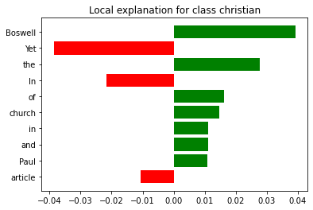

```python
%matplotlib inline
fig = exp.as_pyplot_figure()
```

[figure not shown]

## Limitationen

[figure not shown]

Krech C. Erklärbarkeit maschineller Lernverfahren [Masterarbeit]. Hochschule Darmstadt; 2019.

## Stand der Forschung

- **Fehlende (einheitliche) Handlungsempfehlungen**

[figure not shown]

Krech C. Erklärbarkeit maschineller Lernverfahren [Masterarbeit]. Hochschule Darmstadt; 2019.

## Fazit

- **Grundsätzliches Problem: Kompromiss aus erklärbarem Modell und guter Vorhersagegenauigkeit**
- **Zahlreiche Verfahren zur Erklärung der Entscheidungen von Black-Box-Verfahren**
- **Unternehmen besitzen kaum Erfahrung im Umgang mit diesen Methoden**

## Quellen

- https://storage.googleapis.com/petbacker/images/blog/2017/dog-and-cat-cover.jpg
- https://i.pinimg.com/originals/96/9a/6f/969a6fd7759f2b2aa7fb8763e4e5354e.jpg -https://1.bp.blogspot.com/-_8iPe2Ba6SI/Wkg8qzvHYAI/AAAAAAAAh9Y/lSLeKyzsrmM8K85tNgF8Pa5__lEwiGqBACLcBGAs/s160/cats-image-humorous-buggy-illustration.jpg
- https://media.istockphoto.com/photos/the-big-shaggy-cat-is-very-funny-standingnumber-2-picture-id686556152?k=6&m=686556152&s=612x612&w=0&h=DZgaPK_2RhGwAK_ZiWj1oTJNC6WiBshPutNL-QTKXlg=
- https://upload.wikimedia.org/wikipedia/commons/thumb/f/fe/American_Eskimo_Dog_1.jpg/220px-American_Eskimo_Dog_1.jpg
- https://i.ytimg.com/vi/8jAkTfD86os/hqdefault.jpg
- https://scikit-learn.org/0.19/datasets/twenty_newsgroups.html
- https://christophm.github.io/interpretable-ml-book/pdp.html
- https://www.fbmn.h-da.de/uploads/Themen/WS18_poster_krech.pdf